# Data Wrangling Assignment 5

Yaniv Bronshtein

2/28/2021

**Import the necessary libraries**

```r
library(tidyverse)
library(broom)
library(gapminder)
library(rsample)
```

# Problem 1

In this exercise we will work with the total number of words spoken by characters of different races and genders in the Lord of the Rings movies.  
1.Get the data in a single data frame  
Create 3 data frames (or tibbles) from these files:

```r
fellowship_t <- read_csv("https://raw.githubusercontent.com/jennybc/lotr-tidy/master/data/The_Fellowship_Of_The_Ring.csv") %>% as_tibble()
two_towers_t <- read_csv("https://raw.githubusercontent.com/jennybc/lotr-tidy/master/data/The_Two_Towers.csv") %>% as_tibble()
return_t <- read_csv("https://raw.githubusercontent.com/jennybc/lotr-tidy/master/data/The_Return_Of_The_King.csv") %>% as_tibble()
```

2. Tidy the combined data frame by creating new variables “Gender” and “Words”  
   **Use bind_rows to sequentially append all the tibbles to each other** **Then, use pivot_longer() to convert the Male and Female columns to values in the Gender column** **In turn, move the values originally in these columns to a new column called Words**

```r
lotr_t <- fellowship_t%>%bind_rows(two_towers_t) %>% bind_rows(return_t)
lotr_t <- lotr_t %>% pivot_longer(cols = c("Female", "Male"), names_to = "Gender", values_to = "Words")
```

3.Use the combined data frame to answer the following questions  
a)How many words were spoken in each movie?  
**First, create a tibble by grouping lotr_t by Film and then using summarise() to create a new column total_words based** **on the film groups**

```r
total_movie_wc_t <- lotr_t %>% group_by(Film) %>% summarise(total_words=sum(Words))
```

**Next, derive the count in the first film by using str_detect on the Film column to filter the dataframe,** **pulling out the column in vector form, and then converting the result to a numeric value** **Repeat thuis step for the other two movies**

```r
count_fellowship <- total_movie_wc_t %>% filter(str_detect(Film, "Fellow")) %>% pull(total_words) %>% as.numeric()
cat("The Fellowship of the Ring Total Word Count", count_fellowship)
```

```
## The Fellowship of the Ring Total Word Count 7853
```

```r
count_towers <- total_movie_wc_t %>% filter(str_detect(Film, "Tower")) %>% pull(total_words) %>% as.numeric()
cat("The Two Towers Total Word Count", count_towers)
```

```
## The Two Towers Total Word Count 7297
```

```r
count_return <- total_movie_wc_t %>% filter(str_detect(Film, "Return")) %>% pull(total_words) %>% as.numeric()
cat("The Return of the King Total Word Count", count_return)
```

```
## The Return of the King Total Word Count 6095
```

b)How many words were spoken by each gender in total?  
**First, create a tibble by grouping lotr_t by Gender and then using summarise() to create a new column words_by_gender based on the Gender groups**

```r
words_by_gender_t <- lotr_t %>% group_by(Gender) %>% summarise(words_by_gender = sum(Words))
```

**Next, derive the count of males and females by filtering on Male and Female respectively** **pulling out the column in vector form, and then converting the result to a numeric value**

```r
male_wc <- words_by_gender_t %>% filter(Gender=="Male") %>% pull(words_by_gender) %>% as.numeric()
cat("Total words spoken by men", male_wc)
```

```
## Total words spoken by men 18817
```

```r
female_wc <- words_by_gender_t %>% filter(Gender=="Female") %>% pull(words_by_gender) %>% as.numeric()
cat("Total words spoken by women", female_wc)
```

```
## Total words spoken by women 2428
```

c)How many words were spoken by each race in total?  
**First, create a tibble by grouping lotr_t by Race and then using summarise() to create a new column words_by_race based on the Race groups**

```r
words_by_race_t <- lotr_t %>% group_by(Race) %>% summarise(words_by_race = sum(Words))
```

**Next, derive the count of each race filtering the Race column,** **pulling out the column in vector form, and then converting the result to a numeric value**

```r
elf_wc <- words_by_race_t %>% filter(Race == "Elf") %>% pull(words_by_race) %>% as.numeric()
cat("Total words spoken by elves", elf_wc)
```

```
## Total words spoken by elves 3737
```

```r
hobbit_wc <- words_by_race_t %>% filter(Race == "Hobbit") %>% pull(words_by_race) %>% as.numeric()
cat("Total words spoken by Hobbits", hobbit_wc)
```

```
## Total words spoken by Hobbits 8796
```

```r
man_wc <- words_by_race_t %>% filter(Race == "Man") %>% pull(words_by_race) %>% as.numeric()
cat("Total words spoken by Man", man_wc)
```

```
## Total words spoken by Man 8712
```

4.Create a data frame with totals by race and movie, calling it by_race_film.

```r
by_race_film_t <- lotr_t %>% group_by(Film, Race) %>% summarise(words_by_race_movie = sum(Words))
by_race_film_t
```

```
## # A tibble: 9 x 3
## # Groups:   Film [3]
##   Film                       Race   words_by_race_movie
##   <chr>                      <chr>                <dbl>
## 1 The Fellowship Of The Ring Elf                   2200
## 2 The Fellowship Of The Ring Hobbit                3658
## 3 The Fellowship Of The Ring Man                   1995
## 4 The Return Of The King     Elf                    693
## 5 The Return Of The King     Hobbit                2675
## 6 The Return Of The King     Man                   2727
## 7 The Two Towers             Elf                    844
## 8 The Two Towers             Hobbit                2463
## 9 The Two Towers             Man                   3990
```

# Problem 2

1.Split/group the gapminder data by country. For each country,  
fit an ARIMA(0,0,1) or MA(1) model to lifeExp, and produce a tibble that  
the country-wise values of AIC and BIC, two measures of goodness of  
model fit. Obtain a scatter plot of AIC versus BIC and comment.

**Convert gapminder data set to tibble form**

```r
gapminder_t <- gapminder %>% as_tibble()
```

**Create a function compute_aic_bic() to generate a tibble containing the country name,** **AIC, and BIC in that order**

```r
#This function returns a tibble containing the country, AIC, BIC
# Params:
#p1: number of AR coefficients
#p2: number of differences
#p3: number of MA coefficients
compute_aic_bic = function(p1, p2, p3) {

  #Split the gapminder_t by country using group_split().
  #Use map to apply arima() with order based on function input
  #Use map again to apply the broom function glance() to receive model level information
  #(AIC and BIC)
  countries_arima <- gapminder_t %>%
  group_by(country) %>%
  group_split() %>%
  map(~arima(.$lifeExp, order = c(p1, p2, p3))) %>%
  map(glance)

  #Extract AIC and BIC in vector form using map_dbl()
  countries_aic <- countries_arima %>% map_dbl(~.$AIC)
  countries_bic <- countries_arima %>% map_dbl(~.$BIC)
  #Create a tibble by combining the countries(removing duplicates using the unique())
  #function, and adding the extracted AIC and BIC to the end
  countries_t <- gapminder_t %>% select(country) %>%
  unique() %>%
  mutate(AIC = countries_aic) %>%
  mutate(BIC = countries_bic)

  return(countries_t)
}
```

**Generate the ggplot of AIC vs BIC for ARIMA(0,0,1)**

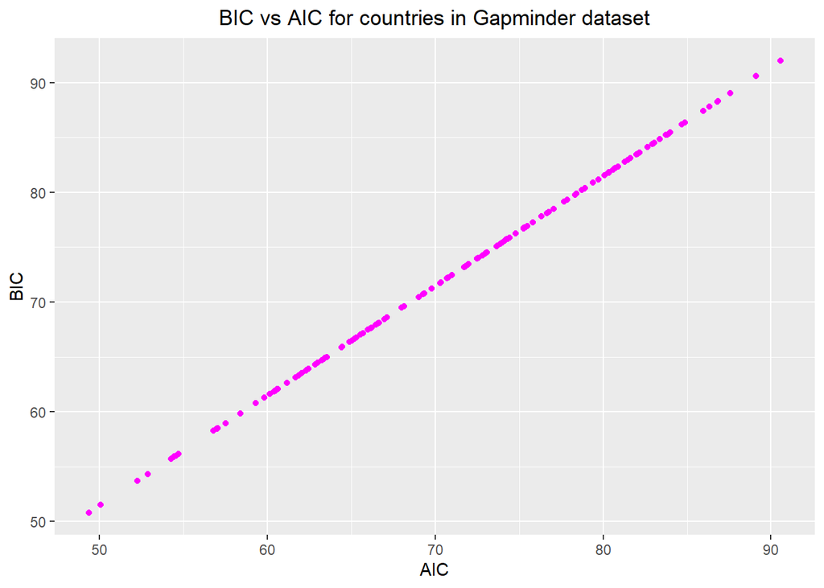

```r
m1 <- compute_aic_bic(0, 0, 1)
ggplot(data = m1 , mapping = aes(x = AIC, y = BIC)) +
  geom_point(color = "Magenta") +
  labs(
    title = "BIC vs AIC for countries in Gapminder dataset"
  ) +
  theme(plot.title = element_text(hjust = 0.5))
```

2.Now repeat the previous step for four other models: ARIMA(0,0,1), ARIMA(0,0,2),  
ARIMA(0,0,3), ARIMA(0,1,0), ARIMA(0,1,1), and in a single plot, show boxplots  
of AIC values for the five models. Based on the boxplot, which of these five  
models do you think fits the data best for most countries?

**In the code below, we will call compute_aic_bic() for the required models** **And create an additional column filled with the corresponding string** **to make plotting easier**

```r
m1 <- m1 %>% mutate(Model = "ARIMA(0,0,1)" )
m2 <- compute_aic_bic(0, 0, 2) %>% select(AIC) %>% mutate(Model = "ARIMA(0,0,2)")
m3 <- compute_aic_bic(0, 0, 3) %>% select(AIC) %>% mutate(Model = "ARIMA(0,0,3)")
m4 <- compute_aic_bic(0, 1, 0) %>% select(AIC) %>% mutate(Model = "ARIMA(0,1,0)")
m5 <- compute_aic_bic(0, 1, 1) %>% select(AIC) %>% mutate(Model = "ARIMA(0,1,1)")
```

```r
models_t <- bind_rows(m1, m2, m3, m4, m5)
```

**Generate the boxplot**

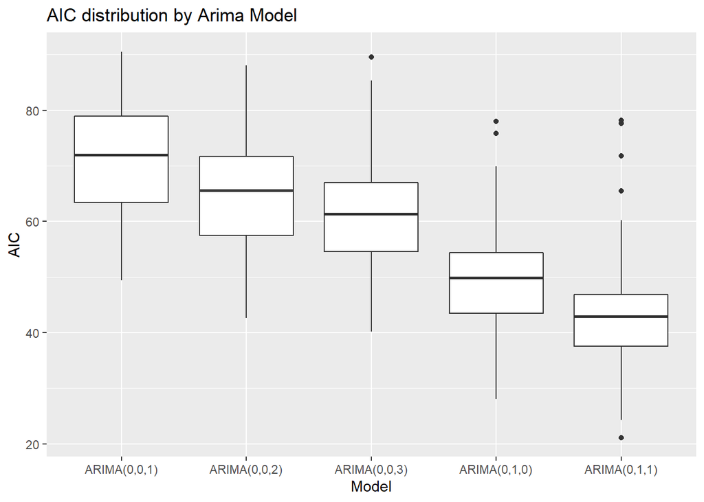

```r
ggplot(data = models_t, mapping = aes(x = Model, y = AIC)) +
  geom_boxplot() +
  labs(title = "AIC distribution by Arima Model")
```

*The best model has the minimal AIC, so ARIMA(0,1,1) wins*

3.Filter the data only for continent Europe.  
For the best model identified in step 2, create a tibble showing the  
country-wise model parameters (moving average coefficients) and their  
errors using the broom package.

**Create a separate dataframe on gapminder just for Europe**

```r
gapminder_europe <- gapminder_t %>% filter(continent == "Europe")
```

**Apply similar logic to that of compute_aic_bic(), replacing glance() with tidy()** **to generate coefficient level data**

```r
countries_arima_europe_tidy <- gapminder_europe %>%
  group_by(country) %>%
  group_split() %>%
  map(~arima(.$lifeExp, order = c(0, 1, 1))) %>%
  map(tidy)

countries_ma_estimate <- countries_arima_europe_tidy %>%
  map_dbl(~.$estimate)
countries_ma_std.error <- countries_arima_europe_tidy %>%
  map_dbl(~.$std.error)

countries_list <- gapminder_europe %>% select(country) %>% unique()
countries_ma_estimate_error_t <-
  tibble(countries_list,
         estimate = countries_ma_estimate, error = countries_ma_std.error)

countries_ma_estimate_error_t
```

```
## # A tibble: 30 x 3
##    country                estimate error
##    <fct>                     <dbl> <dbl>
##  1 Albania                   1.00  0.353
##  2 Austria                   0.708 0.263
##  3 Belgium                   0.645 0.183
##  4 Bosnia and Herzegovina    1.00  0.353
##  5 Bulgaria                  1.00  0.411
##  6 Croatia                   0.676 0.199
##  7 Czech Republic            0.606 0.203
##  8 Denmark                   0.494 0.204
##  9 Finland                   0.778 0.227
## 10 France                    0.706 0.189
## # ... with 20 more rows
```

4.Now filter the data only for year 1992. Plot lifeExp against log10(gdpPercapita). Fit a linear model of lifeExp on log10(gdpPercapita) using population as weights and obtain (i) bootstrapped 95% confidence intervals for the slope coefficient and (ii) bootstrapped 90% prediction intervals for each data point using 500 bootstrapped samples (show a plot of the prediction intervals). Compare the bootstrapped 95% confidence intervals for the estimated slope coefficient with those generated automatically by the lm() function. Which one is wider?

**Step 1: create a filtered tibble on gapminder_t for the year 1992**

```r
gapminder_1992_t <- gapminder_t %>% filter(year == 1992)
```

**Step 2: Generate a linear model to be used as reference and display both coefficient and confidence interval data**

```r
lm_1992 <- gapminder_1992_t %>%
  lm(lifeExp ~ log10(gdpPercap), weights = pop, data = .)

lm_1992_coef <- coef(lm_1992)
cat("LM 1992 coefficients:\n", lm_1992_coef,"\n")
```

```
## LM 1992 coefficients:
##  23.72062 12.04351
```

```r
lm_1992_confint <- confint(lm_1992, level = 0.95)
cat("LM 1992 confidence interval:\n", lm_1992_confint,"\n")
```

```
## LM 1992 confidence interval:
##  17.87865 10.38391 29.5626 13.70311
```

**Step 3: Generate a scatter plot showing Life Expectancy vs log10(gdpPercapita)**

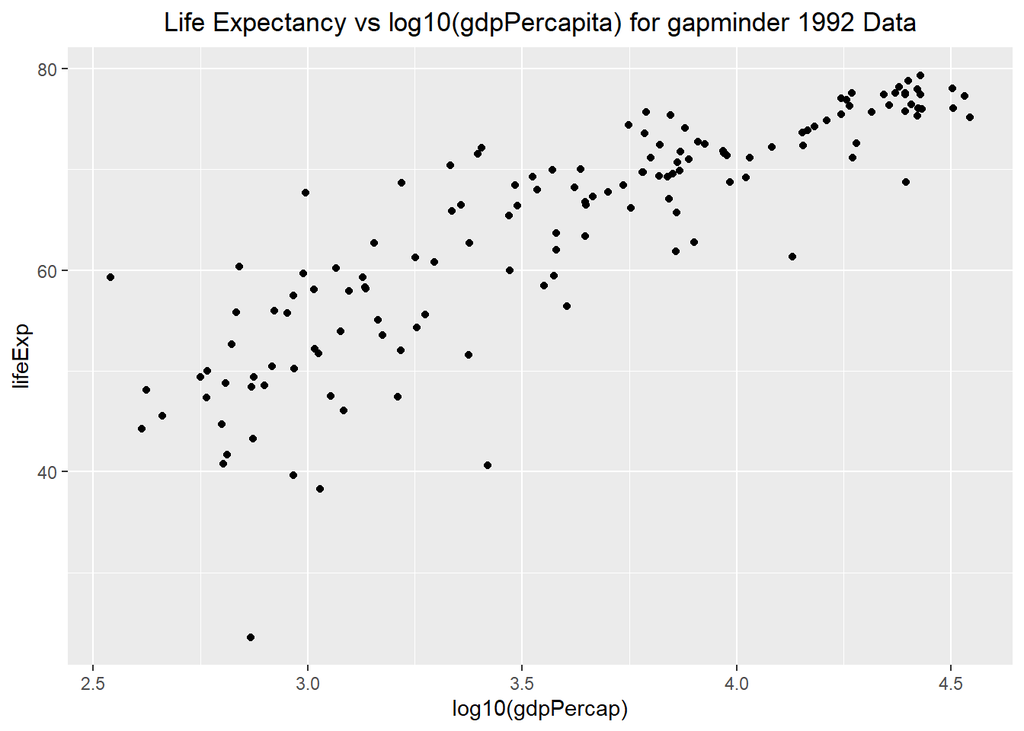

```r
ggplot(data = gapminder_1992_t,
       mapping = aes(x = log10(gdpPercap), y = lifeExp)) +
  geom_point() +
  labs(
    title = "Life Expectancy vs log10(gdpPercapita) for gapminder 1992 Data"
  ) +
  theme(plot.title = element_text(hjust = 0.5))
```

**Step 4: As part of the requirement for part (i) provide bootstrapped 95% confidence intervals for the slope coefficient. Tidy is necessary for this**

```r
set.seed(1)
alpha1 = 0.05
boot_lm <- gapminder_1992_t %>% bootstraps(500)
boot_lm1 <- map(boot_lm$splits, ~as_tibble(.)) %>%
  map(~tidy(lm(lifeExp ~ log10(gdpPercap), weights = pop, data = .))) %>%
  bind_rows(.)
```

**Step 4a. Display the confidence interval together with the median for part (i)**

```r
conf_int_95 <- boot_lm1 %>%
  group_by(term) %>%
  summarise(conf.low = quantile(estimate, alpha1 /2),
                                      conf.high = quantile(estimate, 1 - alpha1 /2),
                                      median = median(estimate))
conf_int_95
```

```
## # A tibble: 2 x 4
##   term             conf.low conf.high median
## * <chr>               <dbl>     <dbl>  <dbl>
## 1 (Intercept)          4.27      34.5   22.7
## 2 log10(gdpPercap)     9.51      16.6   12.3
```

**Step 5: As part of the requirement for part (ii), provide the bootstrapped 90% prediction intervals** **Augment() is now necessary for this**

```r
alpha2 = 0.1
boot_lm2 <- map(boot_lm$splits, ~as_tibble(.)) %>%
  map(~augment(lm(lifeExp ~ log10(gdpPercap), weights = pop, data = .))) %>%
  # Needed to rename because of special characters
  bind_rows(.) %>% rename(log_gdp_percap = names(.)[2])
```

**Step 5a. Display the confidence interval together with the median for part (ii)**

```r
conf_int_90 <- boot_lm2 %>% group_by(log_gdp_percap) %>%
  summarise(conf.low = quantile(.fitted, alpha2 / 2),
            conf.high = quantile(.fitted, 1 - alpha2 / 2),
            median = median(.fitted))

conf_int_90
```

```
## # A tibble: 142 x 4
##    log_gdp_percap conf.low conf.high median
##  *          <dbl>    <dbl>     <dbl>  <dbl>
##  1           2.54     48.4      58.3   54.2
##  2           2.61     48.9      59.0   54.8
##  3           2.62     48.6      58.9   54.8
##  4           2.66     49.7      59.4   55.5
##  5           2.75     50.4      60.3   56.3
##  6           2.76     51.2      60.5   56.8
##  7           2.77     51.0      60.5   56.6
##  8           2.80     51.1      60.8   57.2
##  9           2.80     51.5      61.2   57.5
## 10           2.81     51.6      60.8   57.2
## # ... with 132 more rows
```

**Show a plot of the prediction intervals**

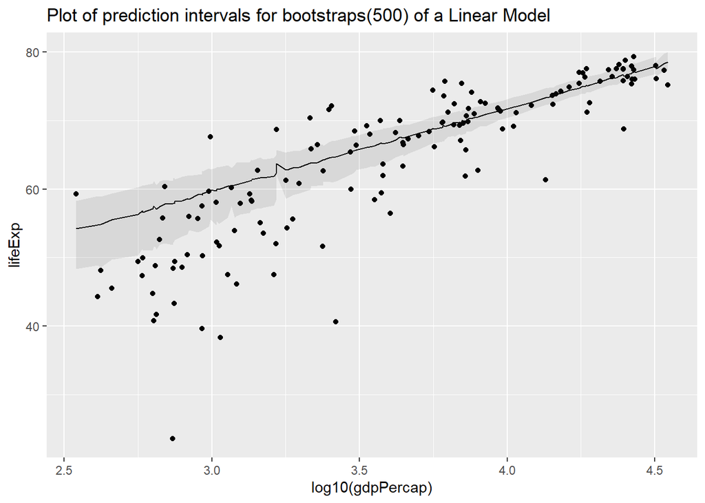

```r
ggplot(conf_int_90) +
  geom_point(aes(x = log_gdp_percap, y = lifeExp), data = boot_lm2) +
  geom_line(aes(x = log_gdp_percap, y = median)) +
  geom_ribbon(aes(x = log_gdp_percap, ymin = conf.low, ymax = conf.high),
              alpha = 0.1) +
  labs(
    title = "Plot of prediction intervals for bootstraps(500) of a Linear Model",
    x = "log10(gdpPercap)")
```

*I believe that the bootstrapped is wider*